# 9.5 Volatility HON

Chris Woodard

July 19, 2016

## Exploratory Analysis of time Series - Stock HON - Honeywell International, Inc.

#### Assignment

1. Download the data for HON.
2. Calculate the log returns.
3. Calculate the volatility measure.
4. Calculate volatility over entire length of series for various three different decay factors.
5. Plot the results, overlaying the volatility curves on the data.

## Financial Series: HON-Honeywell International

#### Honeywell International, Inc. is an American multinational conglomerate company that produces a variety of commercial and consumer products, engineering services and aerospace systems for a wide variety of customers, from private consumers to major corporations and governments. The company operates three business units, known as a Strategic Business Units – Honeywell Aerospace, Honeywell Automation and Control Solutions, and Honeywell Performance Materials and Technologies

### We will use exploratory data analysis to analyze volatility in Honeywell’s stock over time. We will graph the volatility.

#### Libraries needed for financial analysis

```r
require(tseries)
```

#### Load S&P information

```r
SNPdata <- get.hist.quote('^gspc',quote="Close")
```

```r
SNPret <- log(lag(SNPdata)) - log(SNPdata)
SNPvol <- sd(SNPret) * sqrt(250) * 100
```

#### Volatility Measure

```r
Vol <- function(d, logrets){
  var = 0
  lam = 0
  varlist <- c()
  for (r in logrets) {
    lam = lam*(1 - 1/d) + 1
    var = (1 - 1/lam)*var + (1/lam)*r^2
    varlist <- c(varlist, var)
    }
    sqrt(varlist)
}
```

Volatility is the degree of variation of a trading price over time. This is an estimation on the volatility high peakss of the S&P 500. Here we will look at volatility in a continuous lookback window with decays of 10, 30 and 100.

```r
volest <- Vol(10,SNPret)
volest2 <- Vol(30,SNPret)
volest3 <- Vol(100,SNPret)
```

#### Plot S&P 500 with decay factors 10, 30, and 100 days

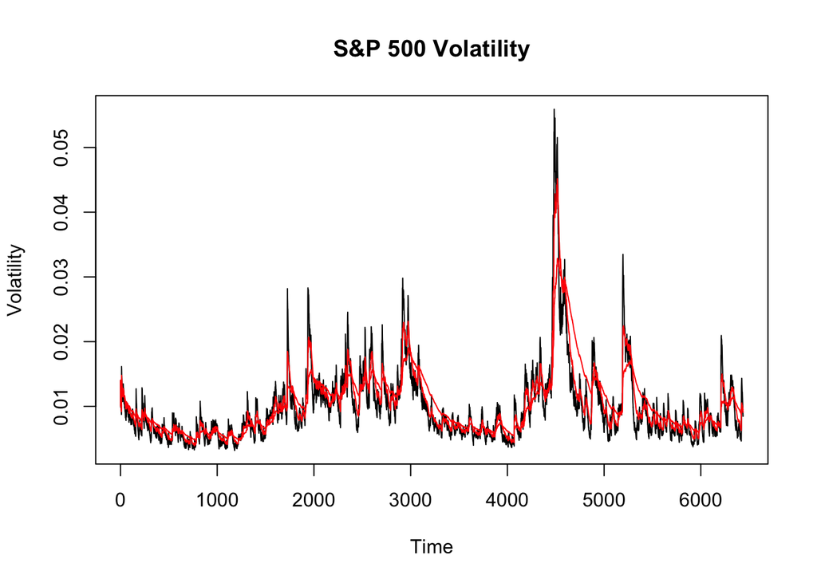

```r
plot(volest,type="l", main="S&P 500 Volatility", xlab="Time", ylab="Volatility")
lines(volest2,type="l",col="red")
lines(volest3, type = "l", col="red")
```

### Honeywell International stock data

[output not shown]

```r
HONret <- log(lag(HONdata)) - log(HONdata)
HONvol <- sd(HONret) * sqrt(250) * 100
```

#### Estimate of overall HON volatility:

```r
HONvol
```

```
## [1] 36.54946
```

Volatility measure (time series with continuous lookback window)

```r
Vol<-function(d, logrets) {
var = 0
lam = 0
varlist <- c()
for (r in logrets){
lam=lam*(1-1/d) + 1
var = (1-1/lam) * var + (1/lam) * r^2
varlist<- c(varlist, var)
}
sqrt(varlist)}
```

Volatility for HON estimated high peaks with d=10, 30, 100 days.

```r
Hvolest10<-Vol(10, HONret)
Hvolest30<-Vol(30, HONret)
Hvolest100<-Vol(100, HONret)
```

#### Plot HON to show all of the decay factors

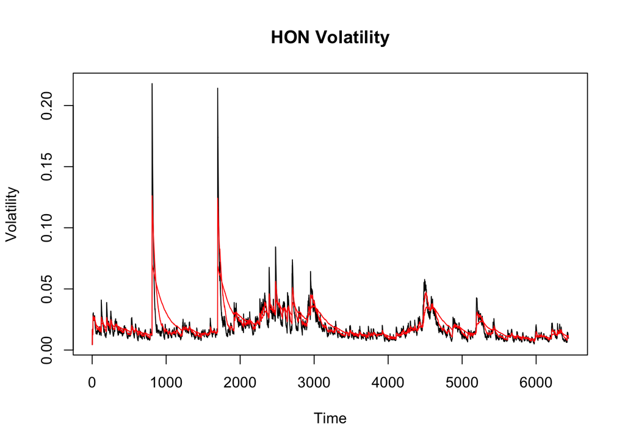

```r
plot(Hvolest10,type="l", main="HON Volatility", xlab="Time", ylab="Volatility")
lines(Hvolest30,type="l",col="red")
lines(Hvolest100, type = "l", col="red")
```